# Analysis of red wine by Dilin John

4. wine density and volatile acidity

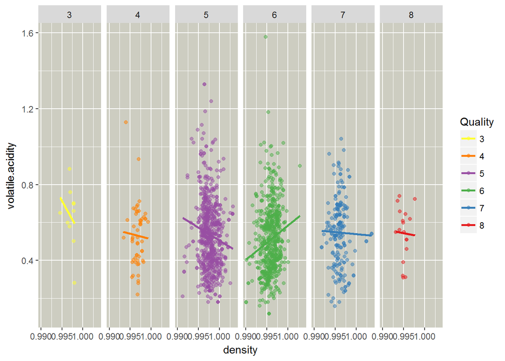

```r
multi_scatter(redwine$density, "density", redwine$volatile.acidity, "volatile.acidity")+
  facet_grid(.~quality)
```

5. alcohol and volatile acidity - the strongest and weakest correlation to quality

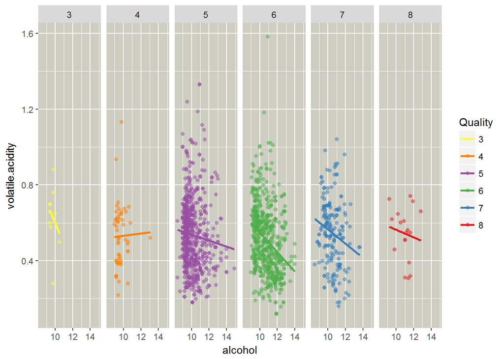

```r
multi_scatter(redwine$alcohol, "alcohol", redwine$volatile.acidity, "volatile.acidity")+
  facet_grid(.~quality)
```

```r
cor(redwine$alcohol, redwine$volatile.acidity)
```

```
## [1] -0.202288
```

6. Trying some linear regression models and output to html

```r
m1 <- lm(formula = I(quality) ~ I(alcohol), data = redwine)
m2 <- update(m1, ~ . + volatile.acidity)
m3 <- update(m2, ~ . + log10(sulphates))
m4 <- update(m3, ~ . + log10(chlorides))
m5 <- update(m4, ~ . + pH)
m6 <- update(m5, ~ . + citric.acid)
m7 <- update(m6, ~ . + free.sulfur.dioxide)

mtable123 <- mtable(m1,m2,m3,m4,m5,m6,m7, sdigits = 3)
write_html(mtable123, file='mtable_redwine.html')
```

From the analysis fo the dataset, the wine quality depends on content of alcohol, citric acid, sulphates and to some extent on fixed acidity. THe quality of redwine improves with lesses volatile acidity, chlorides, total sulfur dioxide to name a few.

### Multivariate Analysis

### Talk about some of the relationships you observed in this part of the investigation. Were there features that strengthened each other in terms of looking at your feature(s) of interest?

Alcohol and sulphates as these were the most positively related to wine quality but I didnt find anything concrete from the plot although there is a negative slope for certain wine grades.The plot between sulphates and citric acid, revealed some interesting features between different wine grades. All wine grades except for grade 8 showed a positive slope between sulphates and citric acid, where was for grade 8, it was negative slope. Grade 3 wine had the highest slope. This seems to indicate in higher quality wines, the relationship between the two is inverse

From the plot between chlorides and density, grade 8 wines has very less variations in chloride content when comapred against the other grades. From this plot it appears that higher grade wines should have controlled chloride content and a density not exceeding 0.9975

### OPTIONAL: Did you create any models with your dataset? Discuss the strengths and limitations of your model.

A linear model was attempted based on the wine quality and alcohol and also added other features like chloride, citric acid, log10 of sulphates, but it didn’t provide any new information than what was already available. A low R- squared value a linear model was not quite a good fit in predicting, based on low R-squared values

# Final Plots and Summary

### Plot One

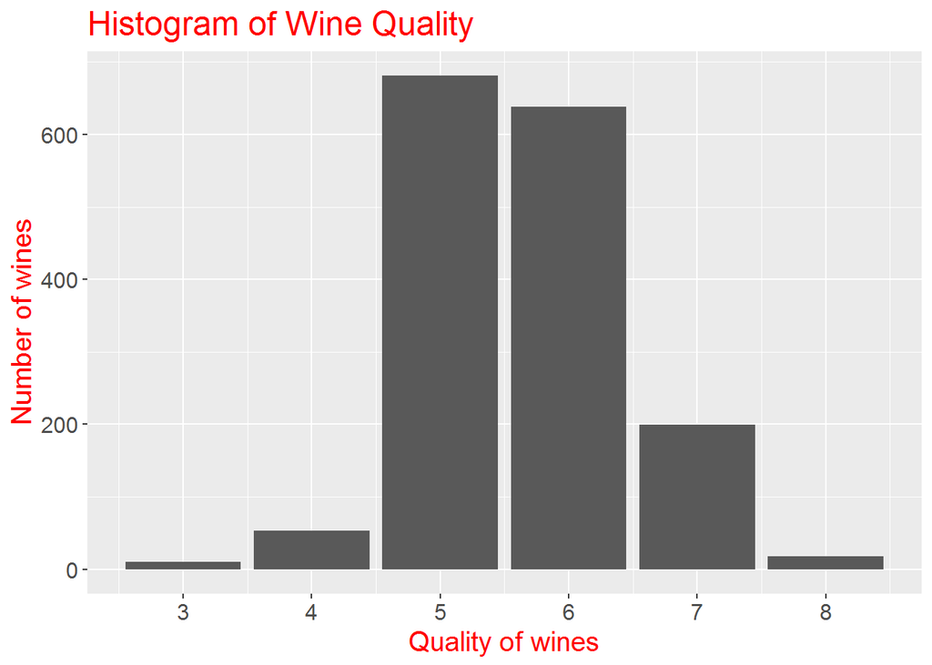

```
##
##   3   4   5   6   7   8
##  10  53 681 638 199  18
```

### Description One

From thw dataset provided, larger samples are of mediocre wines of grade 5 and 6, and they make up more than 80% of the total samples provided. Number of samples of grade 8 is only 18 out of 1599. Combined with grade 7, they together make up only 13.6% of the total sample size, which means there are only few samples to analyze wine quality for good wines and this can be taken from the perspective of features of the mediocre wines.

### Plot Two

plot of wine quality with alcohol

[figure not shown]

```
## redwine$quality: 3
##    Min. 1st Qu.  Median    Mean 3rd Qu.    Max.
##   8.400   9.725   9.925   9.955  10.575  11.000
## --------------------------------------------------------
## redwine$quality: 4
##    Min. 1st Qu.  Median    Mean 3rd Qu.    Max.
##    9.00    9.60   10.00   10.27   11.00   13.10
## --------------------------------------------------------
## redwine$quality: 5
##    Min. 1st Qu.  Median    Mean 3rd Qu.    Max.
##     8.5     9.4     9.7     9.9    10.2    14.9
## --------------------------------------------------------
## redwine$quality: 6
##    Min. 1st Qu.  Median    Mean 3rd Qu.    Max.
##    8.40    9.80   10.50   10.63   11.30   14.00
## --------------------------------------------------------
## redwine$quality: 7
##    Min. 1st Qu.  Median    Mean 3rd Qu.    Max.
##    9.20   10.80   11.50   11.47   12.10   14.00
## --------------------------------------------------------
## redwine$quality: 8
##    Min. 1st Qu.  Median    Mean 3rd Qu.    Max.
##    9.80   11.32   12.15   12.09   12.88   14.00
```

```
## [1] 0.4761663
```

### Description Two

This plot reemphasizes the strong correlation between alcohol content and wine quality and the geom_smooth line summarises this very well in ‘green’. The scatter plot is showing the distribution of samples and as seen earlier we have the highest denisty of scatter for grades 5 and 6. The box plot reveals that the grade 8 wine has the highest median and when compared to the next lower grade 7 wine, median or mid-qaurtile of grade 8 is higher than the upper quartile of grade 7.

### Plot Three

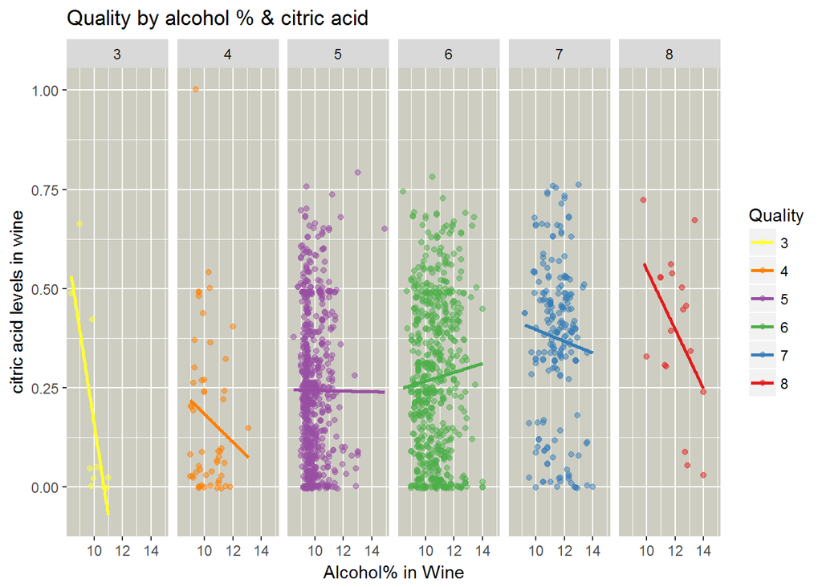

### Reflection

Using the univarite plots was helpful in understanding the dsitributon of wine samples. With the box plots it was easier to visualize how the samples were distributed with respect to the median. log10 transformation plots were also used to examine when the plots were bimodal or skewed. in some cases it helpe, but in some cases it made no change

In the bivariate analysis, I examined wine quality againts other features to see which combinations produce the best quality of wine and it was rather clear from the plots that higher alcohol and less chlorides were present in good quality wines

The linear model created was not accurate in predicting the wine quality as this was reflected in the low R- sqaured values.

Number of samples of each wine grade

3 - 10

4 - 53

5 - 681

6 - 638

7 - 199

8 - 18

majority of the sample are of average grade that is in between 5 and 6. Number of grade 5 samples = 681 NUmber of grade 6 sampled = 638 Together they account for 1319 samples out of 1599 or 82.4% of the toatal dataset More than 75% of the wine samples have a alcohol content less than 11% Distribution is skewed to the right for normal histogram plots for alcohol, suplhates, sulphur dioxide, residual sugar more than 75% of our sample have citric acid levels below 0.5 Most of the wines have a denisty of 0.99XX The most normal distribution is observered for pH and density.

The linear model would have presumably have had a better predition if there had been an equal represenation of all wine grades. Beside high grade grapes, temperature of storing, fermentation all these factor in when a high quality wines to be produced.